# Linear model parameters

## Objectives

- Understand how to interpret R output and parameters in linear models
- Be able to describe the difference between an interactive and additive model
- Plot predictions from additive and interactive linear models

## Model parameters: definitions

- Parameters of a linear model typically characterize *differences* in means
- These are differences per unit of change for *continuous* predictors,
- These are differences between groups (or between group averages) for *categorical* predictors
- Interactions are **differences between differences**

## Coding for categorical predictors: contrasts

- What do the parameters of a linear model mean?
- Start with categorical variables, because they’re potentially more confusing (“intercept and slope” isn’t too hard)
- Default R behaviour: *treatment contrasts*
  - \(\beta_1\) = expected value in baseline group (= first level of the factor variable, by default the first in alphabetical order);
  - \(\beta_i\) = expected difference between group \(i\) and the first group.

## Example

- All model building is about hypothesis testing
- It important to understand which variables go on the *x-axis* and might determine patterns in your *y* (response variable)
- I want to test the hypothesis that the number of ant colonies (*y*) is higher in one place (*x*) than another.
- My *places* are field and forest - two categorical *parameters* of the *place* variable

## The previously explored ant-colony example:

Define data:

```r
forest <- c(9, 6, 4, 6, 7, 10)
field  <- c(12, 9, 12, 10)
ants <- data.frame(
  place=rep(c("field","forest"),
            c(length(field), length(forest))),
  colonies=c(field,forest),
    observers=c(1,3,2,1,5,2,1,2,1,1)
)
## utility function for pretty printing
pr <- function(m) printCoefmat(coef(summary(m)),
                        digits=3,signif.stars=FALSE)
```

```r
pr(lm1 <- lm(colonies~place,data=ants))
```

```
##             Estimate Std. Error t value Pr(>|t|)
## (Intercept)    10.75       0.98   10.97  4.2e-06
## placeforest    -3.75       1.27   -2.96    0.018
```

- The `(Intercept)` row refers to \(\beta_1\), which is the mean density in the “field” sites (“field” comes before “forest”).
- The `placeforest` row indicates we are looking at the effect of `forest` level of the `place` variable, i.e. the difference between “forest” and “field” sites. (To know that “field” is the baseline level we must (1) remember, or look at `unique(ants$place)` or (2) notice which level is *missing* from the list of parameter estimates.)

## Figuring out the estimated values, not the differences

R’s behaviour may seem annoying at first – it seems like the estimated values of the groups are what we’re really interested in – but it is really designed for testing *differences among groups*. To get the estimates per group, you could:

- `predict` (base R)
- `emmeans` - package emmeans
- `plot(allEffects(mod1))` - package effects
- For your assignment this week, you will can you use the others, but your final graph should use `predict`

## Interpretation using `predict`

- Use the `predict` function:

```r
predict(lm1,newdata=data.frame(place=c("field","forest")),
        interval="confidence")
```

```
##     fit      lwr       upr
## 1 10.75 8.489484 13.010516
## 2  7.00 5.154296  8.845704
```

## Interpretation using `effects` package

- Use the `effects` package:

```r
library("effects")
summary(allEffects(lm1))
```

```
##  model: colonies ~ place
##
##  place effect
## place
##  field forest
##  10.75   7.00
##
##  Lower 95 Percent Confidence Limits
## place
##    field   forest
## 8.489484 5.154296
##
##  Upper 95 Percent Confidence Limits
## place
##     field    forest
## 13.010516  8.845704
```

## Interpretation using `emmeans` package

- Use the `emmeans` package:

```r
library("emmeans")
emmeans(lm1,specs=~place)
```

```
##  place  emmean   SE df lower.CL upper.CL
##  field    10.8 0.98  8     8.49    13.01
##  forest    7.0 0.80  8     5.15     8.85
##
## Confidence level used: 0.95
```

## Graphical summaries from `effects` package

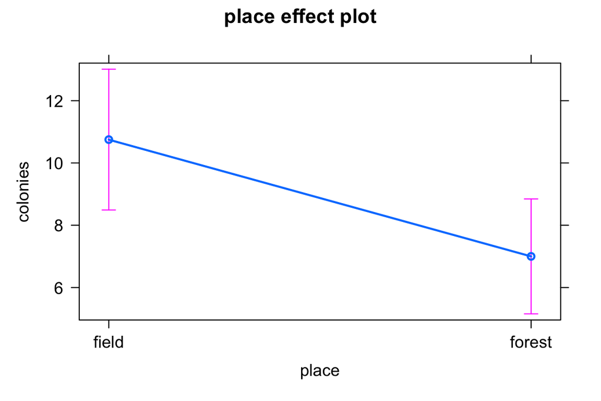

```r
plot(allEffects(lm1))
```

## The `effects` package works on more complicated models

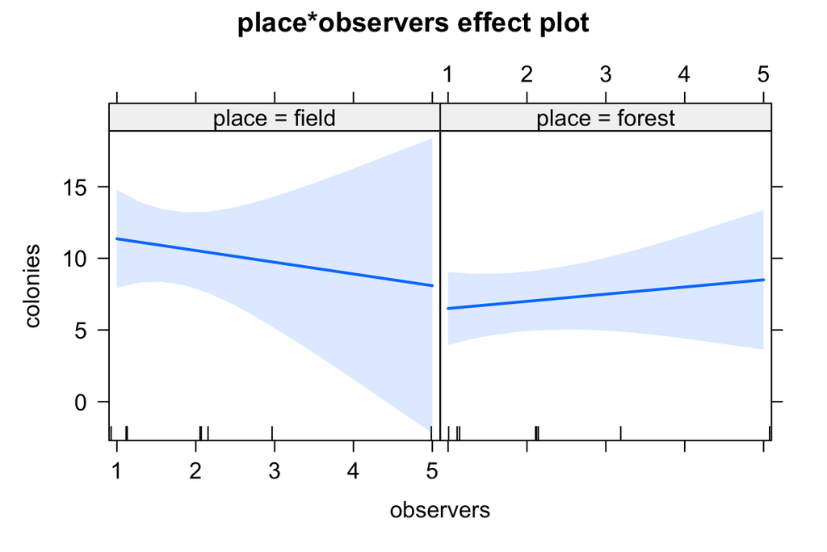

```r
lm3 <- lm(colonies~place*observers,data=ants)
plot(allEffects(lm3))
```

## Switching to a dataset with more than two levels

Some data on lizard perching behaviour (`brglm` package; Schoener 1970 *Ecology* **51**:408-418).

```r
lizards <- read.csv("lizards.csv")
```

Response is number of *Anolis grahami* lizards found on perches in particular conditions.

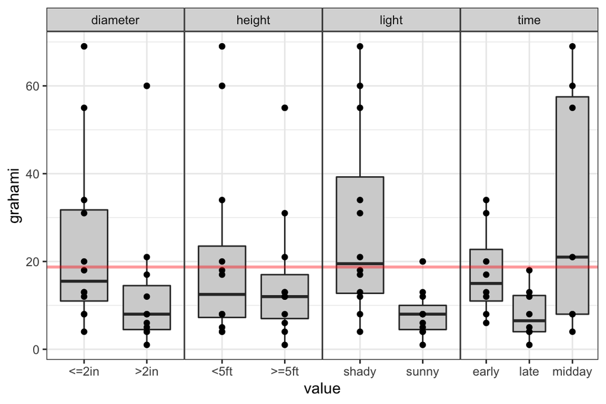

## What is the effect of time of day on lizard perching?

```r
pr(lmX <- lm(grahami~time,data=lizards))
```

```
##             Estimate Std. Error t value Pr(>|t|)
## (Intercept)    17.63       5.97    2.95   0.0079
## timelate       -9.50       8.44   -1.13   0.2739
## timemidday     14.52       8.74    1.66   0.1123
```

If we leave the factors alphabetical then \(\beta_1\)=“early”, \(\beta_2\)=“late”-“early”, \(\beta_3\)=“midday”-“early”. It might be more sensible to change the levels in accordance with time progression.

## Change the order of the levels:

```r
lizards <- mutate(lizards,
        time=factor(time,
            levels=c("early","midday","late")))
```

This just swaps the definitions of \(\beta_2\) and \(\beta_3\).

```r
pr(lmX <- lm(grahami~time,data=lizards))
```

```
##             Estimate Std. Error t value Pr(>|t|)
## (Intercept)    17.63       5.97    2.95   0.0079
## timemidday     14.52       8.74    1.66   0.1123
## timelate       -9.50       8.44   -1.13   0.2739
```

## Multiple treatments and interactions

## Additive model

Consider the `light` variable in addition to `time`.

```r
pr(lmTL1 <- lm(grahami~time+light,data=lizards))
```

```
##             Estimate Std. Error t value Pr(>|t|)
## (Intercept)    27.29       5.63    4.85  0.00011
## timemidday     13.14       7.11    1.85  0.08010
## timelate       -9.50       6.85   -1.39  0.18174
## lightsunny    -19.32       5.73   -3.37  0.00321
```

## Graphical interpretation

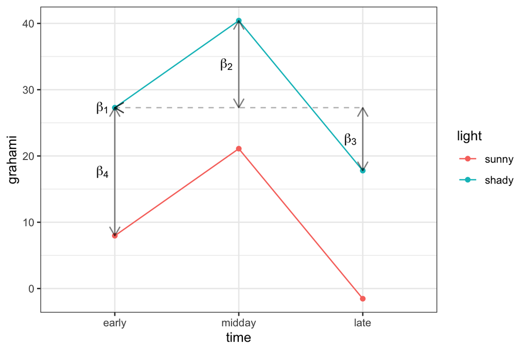

## What are the p-values?

```r
pr(lmTL2 <- lm(grahami~time+light,data=lizards))
```

```
##             Estimate Std. Error t value Pr(>|t|)
## (Intercept)    27.29       5.63    4.85  0.00011
## timemidday     13.14       7.11    1.85  0.08010
## timelate       -9.50       6.85   -1.39  0.18174
## lightsunny    -19.32       5.73   -3.37  0.00321
```

The p-values tell us the difference from the baseline level, not from each other

## Assessing differences among pairs of variable levels - load packages

```r
library(emmeans)
library(multcompView)
library(multcomp)
```

## Assessing differences among pairs of variable levels

```r
emmeans(lmTL1, specs = "time", contr = "pairwise")
```

```
## $emmeans
##  time   emmean   SE df lower.CL upper.CL
##  early   17.62 4.85 19     7.48     27.8
##  midday  30.76 5.20 19    19.89     41.6
##  late     8.12 4.85 19    -2.02     18.3
##
## Results are averaged over the levels of: light
## Confidence level used: 0.95
##
## $contrasts
##  contrast       estimate   SE df t.ratio p.value
##  early - midday    -13.1 7.11 19  -1.849  0.1810
##  early - late        9.5 6.85 19   1.386  0.3677
##  midday - late      22.6 7.11 19   3.186  0.0129
##
## Results are averaged over the levels of: light
## P value adjustment: tukey method for comparing a family of 3 estimates
```

## Getting an ABCDEF.. list

```r
lsm1<-emmeans(lmTL1,pairwise~time)
cld(lsm1$emmeans,by = NULL, Letters = "ABCDEFGHIJ")
```

```
##  time   emmean   SE df lower.CL upper.CL .group
##  late     8.12 4.85 19    -2.02     18.3  A
##  early   17.62 4.85 19     7.48     27.8  AB
##  midday  30.76 5.20 19    19.89     41.6   B
##
## Results are averaged over the levels of: light
## Confidence level used: 0.95
## P value adjustment: tukey method for comparing a family of 3 estimates
## significance level used: alpha = 0.05
## NOTE: Compact letter displays can be misleading
##       because they show NON-findings rather than findings.
##       Consider using 'pairs()', 'pwpp()', or 'pwpm()' instead.
```

## Notes about compact letter displays

- This ability may be deprecated
- Compact-letter displays (CLDs) encourage a misleading interpretation of significance testing by visually grouping means whose comparisons have P > 0.05 as though they are equal. (Both get the same letter)
- Failing to prove two means are different does not prove that they are the same.

## Interactions

- Interactions allow the value of one predictor to affect the relationship between another predictor and the response variable
- Interpreting *main effects* in the presence of interactions is tricky
- Your estimate of the effect of variable \(X_1\) is no longer constant
- You need to pick a fixed point, or average in some way
- Example: \(Y = a + b_1 X_1 + b_2 X_2 + b_{12} X_1*X_2\)
- The response to \(X_1\) is \(Y = (a+b_2 X_2) + (b_1+b_{12}X_2) X_1\)
- The response to \(X_1\) *depends on* the value of \(X_2\).

## An example

- You think that the number of lizards on a perch on a sunny day might depend on the time day
- For example, on a very sunny day, there might be fewer lizards perching at noon; whereas on a cloudy day, the number of lizards might be highest at noon

## Testing interactions

- Time is an important factor
- Use an *interaction*: \[ M = a + B_x X + B_t t + B_{xt} Xt \]
- The interaction term \(B_{xt}\) represents the *difference in the response* between the two groups.
- It asks: **does the number of lizards perching depend on time of day and light?**
- Could also write: \[ M = a + B_1 light + B_2 time + B_{3} light*time \]

## Treatment and interactions

- We previously discussed the wrong construction of linear models to compare drug treatments in mutant and non-mutant mice (erroneous interactions)
- You want to know whether a drug that significantly reduces neuronal firing affects mutant or control mice differently
- You find that the drug sig. decreases neuronal firing in mutant mice
- The drug doesn’t decrease sig. dec neuronal firing in non-mutants
- You need mouse_type*trmt to understand whether the treatment affects mice differently!

## Interactions and parameters

- We can use CIs, and coefficient plots, and get a pretty good idea what’s going on
- In more complicated cases, interaction terms may have many parameters
- These have all the interpretation problems of other multi-parameter variables
- Think about “differences in differences”

## Interaction model

```r
pr(lmTL2 <- lm(grahami~time*light,data=lizards))
```

```
##                       Estimate Std. Error t value Pr(>|t|)
## (Intercept)              23.50       5.38    4.37  0.00042
## timemidday               27.75       7.60    3.65  0.00198
## timelate                -12.75       7.60   -1.68  0.11180
## lightsunny              -11.75       7.60   -1.55  0.14061
## timemidday:lightsunny   -32.83      11.19   -2.93  0.00927
## timelate:lightsunny       6.50      10.75    0.60  0.55343
```

- Parameters \(\beta_1\) to \(\beta_4\) have the same meanings as before.
- \(\beta_5\) and \(\beta_6\), labelled “timemidday:lightsunny” and “timelate:lightsunny” describe the difference between the expected mean value of these treatment combinations based on the additive model

## Interaction model cont

```r
pr(lmTL2 <- lm(grahami~time*light,data=lizards))
```

```
##                       Estimate Std. Error t value Pr(>|t|)
## (Intercept)              23.50       5.38    4.37  0.00042
## timemidday               27.75       7.60    3.65  0.00198
## timelate                -12.75       7.60   -1.68  0.11180
## lightsunny              -11.75       7.60   -1.55  0.14061
## timemidday:lightsunny   -32.83      11.19   -2.93  0.00927
## timelate:lightsunny       6.50      10.75    0.60  0.55343
```

- num lizards when sunny at midday = \(\beta_1 + \beta_2 + \beta_4 + \beta_5\)
- num lizards when sunny at late = \(\beta_1 + \beta_3 + \beta_4 + \beta_6\)

## Graphical version

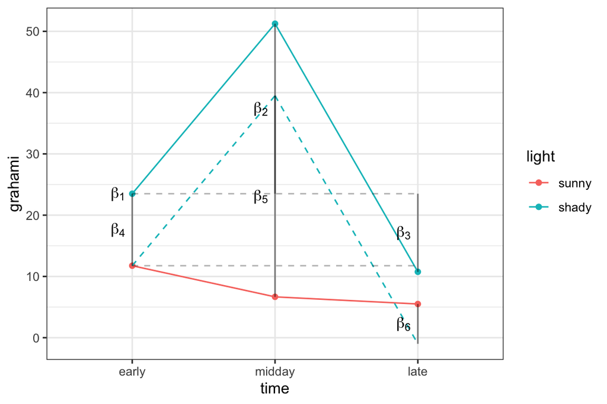

## Effects plot

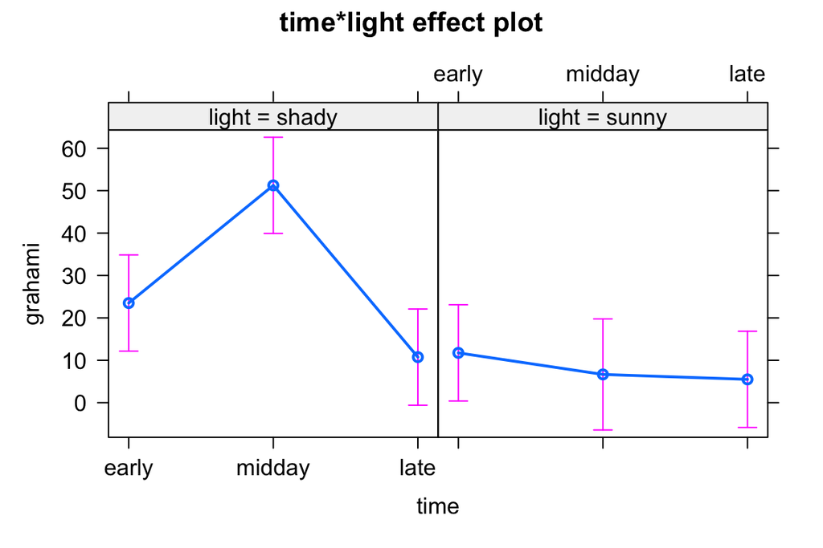

```r
plot(allEffects(lmTL2))
```

## Other refs

- http://sas-and-r.blogspot.com/2010/10/example-89-contrasts.html
- [`gmodels::fit.contrast()`](http://hosho.ees.hokudai.ac.jp/~kubo/Rdoc/library/gmodels/html/fit.contrast.html) (show parameter estimates based on re-fitting models with new contrasts), [`rms::contrast.rms()`](http://hosho.ees.hokudai.ac.jp/~kubo/Rdoc/library/rms/html/contrast.html) (ditto, for `rms`-based fits)
- http://www.ats.ucla.edu/stat/r/library/contrast_coding.htm

## Assignment - *PART 1*

1. Make a univariate linear model for one of your hypotheses
2. Examine the assumptions of linearity (using tests or diagnostic plots) and explain
3. Plot the relationship in ggplot using stat_smooth (continuous) or stat_summary (discrete)

## Assignment - *PART 2*

1. Make a linear model (with more than one variable) for one of your hypotheses. Articulate which hypothesis you are testing.
2. Use an interactive model and an additive model. Explain what hypothesis each of these is testing, and what the R output is telling you about your data. (Hint: you can use emmeans, effects, relevel, or predict to help you.) You should include this explanation in your code.
3. Plot your model (e.g. using predict) and overlay the model on top of the underlying data. See code for example to plot both model and data (on github).